# online-grading

GAN LING

2017/4/19

in this file our original document is KAdebowaleGender_SBU original 050117 test (1).xlsx. I open the file using Excel, then sort it according to StudentNumber column then save it as KAdebowaleGender_SBU.csv file to use

read the data into RStudio

```r
grading = read.csv("KAdebowaleGender_SBU.csv")
```

The purpose of this project is to calculate the correlation between the final grade 1. total Hits (column CW)

```r
data1 = grading[,c("TotalGrade", "TotalDBMFhits")]
```

because the data doesn’t have any NA and NULL data, we don’t need to deal with that create training set and test set

```r
require(caret)
seed = as.numeric(as.Date("2017-04-19"))
set.seed(seed)
inTrain = createDataPartition(data1$TotalGrade, p=0.7)
trainingset <- data1[inTrain[[1]],]
testset = data1[-inTrain[[1]],]
```

draw the plot about the relationship between them

```r
glm.fit = glm(TotalGrade~TotalDBMFhits,data = trainingset)
summary(glm.fit)
```

```
##
## Call:
## glm(formula = TotalGrade ~ TotalDBMFhits, data = trainingset)
##
## Deviance Residuals:
##     Min       1Q   Median       3Q      Max
## -51.437   -2.668    1.647    5.057   10.083
##
## Coefficients:
##               Estimate Std. Error t value Pr(>|t|)
## (Intercept)   86.17303    1.39526  61.761  < 2e-16 ***
## TotalDBMFhits  0.08708    0.01770   4.919 2.08e-06 ***
## ---
## Signif. codes:  0 '***' 0.001 '**' 0.01 '*' 0.05 '.' 0.1 ' ' 1
##
## (Dispersion parameter for gaussian family taken to be 66.62094)
##
##     Null deviance: 12671  on 167  degrees of freedom
## Residual deviance: 11059  on 166  degrees of freedom
## AIC: 1186.2
##
## Number of Fisher Scoring iterations: 2
```

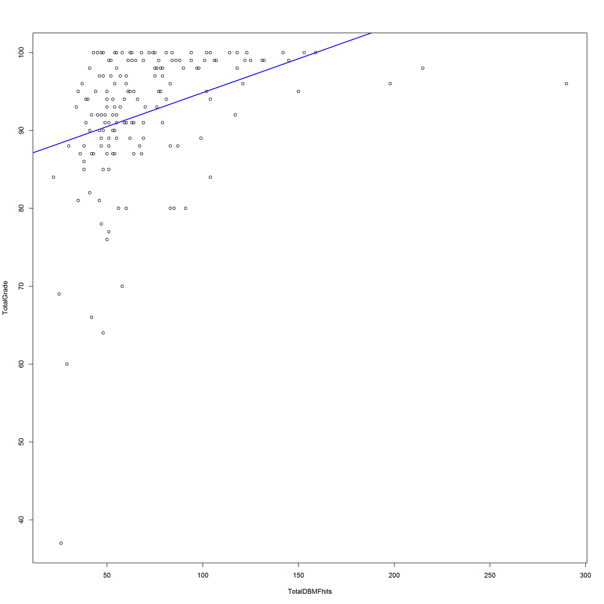

```r
plot(trainingset$TotalDBMFhits, trainingset$TotalGrade, xlab="TotalDBMFhits", ylab="TotalGrade")
abline(glm.fit, col="blue", lwd=2)
```

we can also see the correlation rate between them

```r
library(lsr)
correlate(trainingset, corr.method="spearman" )
```

```
##
## CORRELATIONS
## ============
## - correlation type:  spearman
## - correlations shown only when both variables are numeric
##
##               TotalGrade TotalDBMFhits
## TotalGrade             .         0.458
## TotalDBMFhits      0.458             .
```

then we can use it to test set

```r
glm.probs = predict(glm.fit, newdata = testset, type = "response")
glm.probs[1:5]
```

```
##        2        3        4        5       10
## 89.74329 91.48488 89.91745 89.48205 92.35567
```

```r
glm.pred = as.data.frame(round(glm.probs))
colnames(glm.pred) = c("pred")
calacc = function(x, y, error){
    equal = 0
    total = length(x)
    for (i in 1:total){
        upvalue = y[i] + error
        downvalue = y[i] = error
        if (x[i] >= downvalue && x[i] <= upvalue){
            equal = equal + 1
        }
    }
    acc = equal / total
    acc
}
# calculate the accuracy, the error set to 5 points
calacc(glm.pred$pred, testset$TotalGrade, 5)
```

```
## [1] 0.8714286
```

use CV and loocv to do the model

```r
require(boot)
glm.fit = glm(TotalGrade~TotalDBMFhits,data = trainingset)
cv.glm(trainingset,glm.fit)$delta
```

```
## [1] 68.32554 68.31767
```

```r
loocv=function(fit){
  h=lm.influence(fit)$h
  mean((residuals(fit)/(1-h))^2)
}
loocv(glm.fit)
```

```
## [1] 68.32554
```

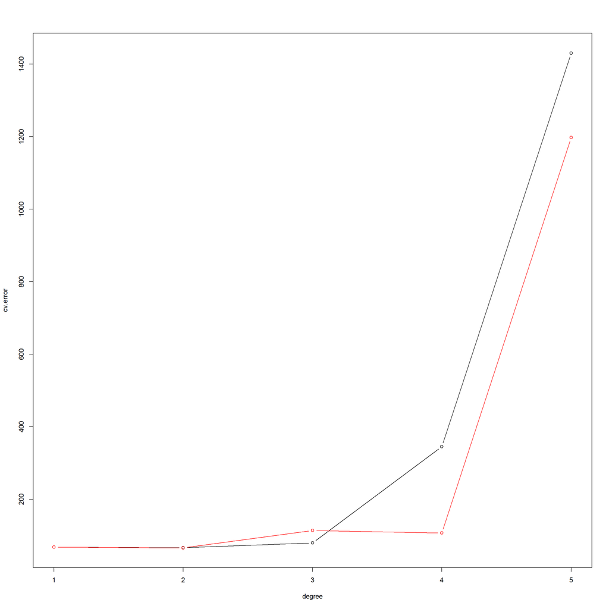

```r
cv.error=rep(0,5)
degree=1:5   ## polomial 1 to 5 degree
for(d in degree){
  glm.fit=glm(TotalGrade~poly(TotalDBMFhits,d), data=trainingset)
  cv.error[d]=loocv(glm.fit)
}
plot(degree,cv.error,type="b")

## 10-fold CV  divide the data 10 parts repeat only 10 times

cv.error10=rep(0,5)
for(d in degree){
  glm.fit=glm(TotalGrade~poly(TotalDBMFhits,d), data=trainingset)
  cv.error10[d]=cv.glm(trainingset,glm.fit,K=10)$delta[1]
}
lines(degree,cv.error10,type="b",col="red")
```

then use SVM model, but nothing insteresting by using this, give up

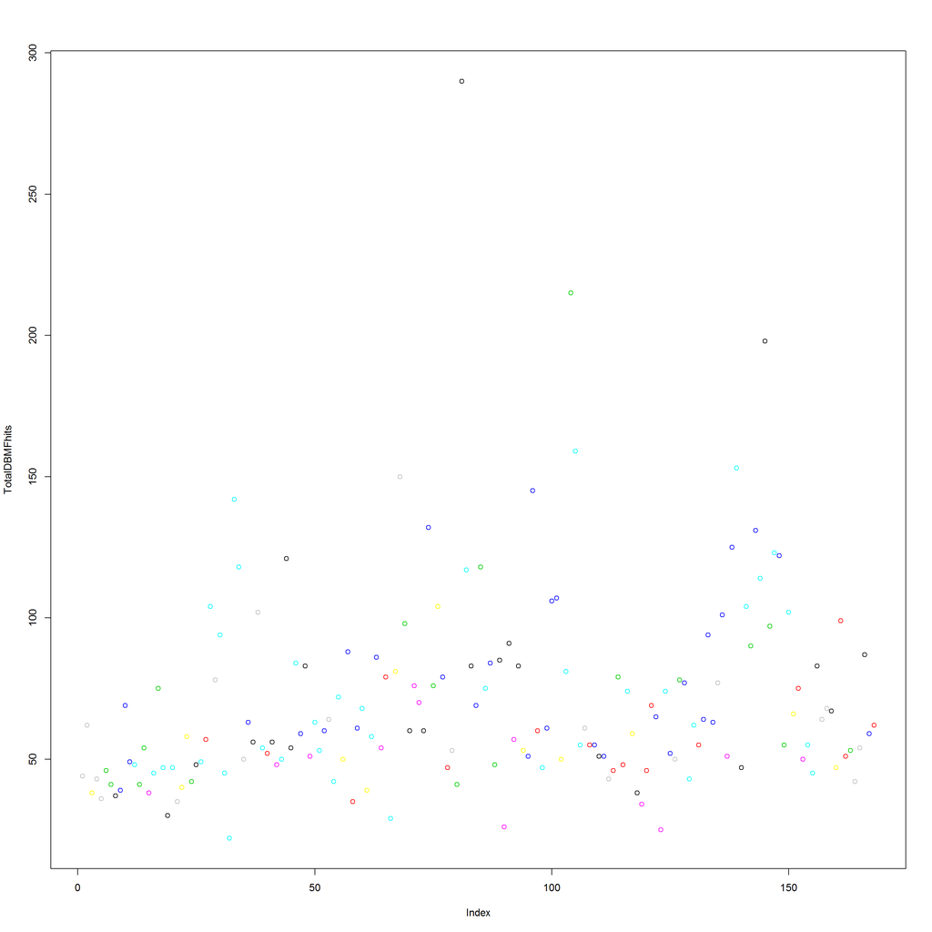

```r
library(e1071)
attach(trainingset)
plot(TotalDBMFhits, col = TotalGrade + 1)
```

```r
dat = data.frame(TotalGrade=factor(TotalGrade),TotalDBMFhits)
fit = svm(factor(TotalGrade)~.,data=dat,scale=FALSE,kernel="radial",cost=5)

# xgrid = expand.grid(X1=px1,X2=px2)
```

2. total time spent in the course ( Column T)

```r
data2 = grading[,c("TotalGrade", "TotalTimeStudentsspentinCourseinHours")]
```

because the data have NA and NULL data, we need to deal with that

```r
cleanNULL = function(x){
   for (i in 1:nrow(x)){
       for (j in 1:ncol(x)){
           if (x[i, j] == "#NULL!"){
              x[i, j] = NA
           }
       }
   }
    x
}
data2 = cleanNULL(data2)
data2 = na.omit(data2)
data2$TotalTimeStudentsspentinCourseinHours = as.integer(data2$TotalTimeStudentsspentinCourseinHours)
```

create training set and test set

```r
seed = as.numeric(as.Date("2017-04-19"))
set.seed(seed)
inTrain = createDataPartition(data2$TotalGrade, p=0.7)
trainingset <- data2[inTrain[[1]],]
testset = data2[-inTrain[[1]],]
```

draw the plot about the relationship between them

```r
glm.fit = glm(TotalGrade~TotalTimeStudentsspentinCourseinHours,data = trainingset)
summary(glm.fit)
```

```
##
## Call:
## glm(formula = TotalGrade ~ TotalTimeStudentsspentinCourseinHours,
##     data = trainingset)
##
## Deviance Residuals:
##     Min       1Q   Median       3Q      Max
## -24.747   -1.474    1.753    4.628   14.024
##
## Coefficients:
##                                       Estimate Std. Error t value Pr(>|t|)
## (Intercept)                            83.5338     3.2196  25.946  < 2e-16
## TotalTimeStudentsspentinCourseinHours   0.4071     0.1467   2.775  0.00891
##
## (Intercept)                           ***
## TotalTimeStudentsspentinCourseinHours **
## ---
## Signif. codes:  0 '***' 0.001 '**' 0.01 '*' 0.05 '.' 0.1 ' ' 1
##
## (Dispersion parameter for gaussian family taken to be 78.53613)
##
##     Null deviance: 3275.0  on 35  degrees of freedom
## Residual deviance: 2670.2  on 34  degrees of freedom
## AIC: 263.19
##
## Number of Fisher Scoring iterations: 2
```

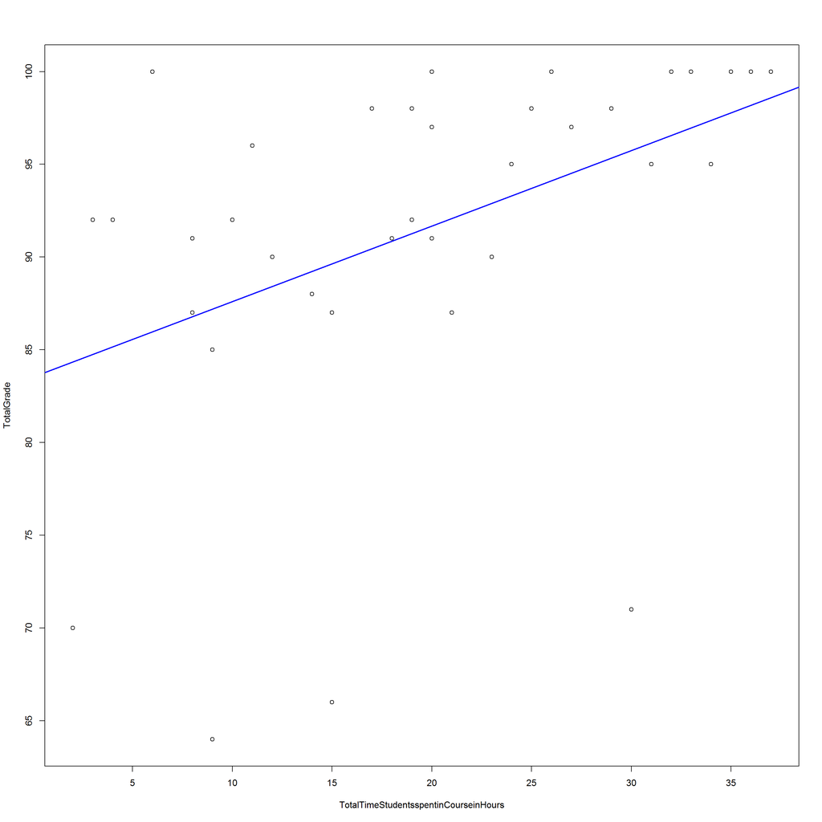

```r
plot(trainingset$TotalTimeStudentsspentinCourseinHours, trainingset$TotalGrade, xlab="TotalTimeStudentsspentinCourseinHours", ylab="TotalGrade")
abline(glm.fit, col="blue", lwd=2)
```

we can also see the correlation rate between them

```r
correlate(trainingset, corr.method="spearman" )
```

```
##
## CORRELATIONS
## ============
## - correlation type:  spearman
## - correlations shown only when both variables are numeric
##
##                                       TotalGrade
## TotalGrade                                     .
## TotalTimeStudentsspentinCourseinHours      0.544
##                                       TotalTimeStudentsspentinCourseinHours
## TotalGrade                                                            0.544
## TotalTimeStudentsspentinCourseinHours                                     .
```

then we can use it to test set

```r
glm.probs = predict(glm.fit, newdata = testset, type = "response")
glm.probs[1:5]
```

```
##        7       10       12       16       20
## 85.56930 87.19769 88.41899 90.45448 88.82609
```

```r
glm.pred = as.data.frame(round(glm.probs))
colnames(glm.pred) = c("pred")
# calculate the accuracy, the error set to 0 points
calacc(glm.pred$pred, testset$TotalGrade, 0)
```

```
## [1] 0.8333333
```

use CV and loocv to do the model

```r
glm.fit = glm(TotalGrade~TotalTimeStudentsspentinCourseinHours,data = trainingset)
cv.glm(trainingset,glm.fit)$delta
```

```
## [1] 83.54205 83.40736
```

```r
loocv=function(fit){
  h=lm.influence(fit)$h
  mean((residuals(fit)/(1-h))^2)
}
loocv(glm.fit)
```

```
## [1] 83.54205
```

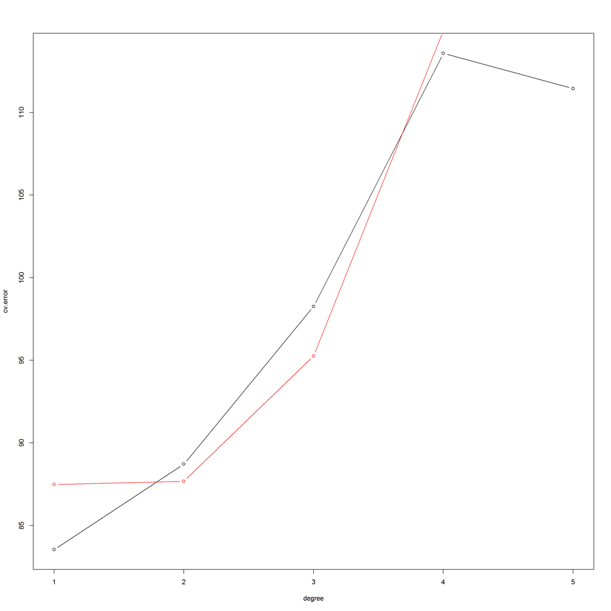

```r
cv.error=rep(0,5)
degree=1:5   ## polomial 1 to 5 degree
for(d in degree){
  glm.fit=glm(TotalGrade~poly(TotalTimeStudentsspentinCourseinHours,d), data=trainingset)
  cv.error[d]=loocv(glm.fit)
}
plot(degree,cv.error,type="b")

## 10-fold CV  divide the data 10 parts repeat only 10 times
cv.error10=rep(0,5)
for(d in degree){
  glm.fit=glm(TotalGrade~poly(TotalTimeStudentsspentinCourseinHours,d), data=trainingset)
  cv.error10[d]=cv.glm(trainingset,glm.fit,K=10)$delta[1]
}
lines(degree,cv.error10,type="b",col="red")
```

3. Both Total Hits and Total Time

```r
data3 = grading[,c("TotalGrade", "TotalDBMFhits", "TotalTimeStudentsspentinCourseinHours")]
```

because the data have NA and NULL data, we need to deal with that

```r
data3 = cleanNULL(data3)
data3 = na.omit(data3)
data3$TotalTimeStudentsspentinCourseinHours = as.integer(data3$TotalTimeStudentsspentinCourseinHours)
```

create training set and test set

```r
seed = as.numeric(as.Date("2017-04-19"))
set.seed(seed)
inTrain = createDataPartition(data3$TotalGrade, p=0.7)
trainingset <- data3[inTrain[[1]],]
testset = data3[-inTrain[[1]],]
```

using glm to do the train

```r
glm.fit = glm(TotalGrade~.,data = trainingset)
summary(glm.fit)
```

```
##
## Call:
## glm(formula = TotalGrade ~ ., data = trainingset)
##
## Deviance Residuals:
##     Min       1Q   Median       3Q      Max
## -23.469   -1.977    1.865    4.582   14.021
##
## Coefficients:
##                                       Estimate Std. Error t value Pr(>|t|)
## (Intercept)                           81.58454    4.18679  19.486   <2e-16
## TotalDBMFhits                          0.05442    0.07399   0.736   0.4672
## TotalTimeStudentsspentinCourseinHours  0.36053    0.16070   2.244   0.0317
##
## (Intercept)                           ***
## TotalDBMFhits
## TotalTimeStudentsspentinCourseinHours *
## ---
## Signif. codes:  0 '***' 0.001 '**' 0.01 '*' 0.05 '.' 0.1 ' ' 1
##
## (Dispersion parameter for gaussian family taken to be 79.61059)
##
##     Null deviance: 3275.0  on 35  degrees of freedom
## Residual deviance: 2627.1  on 33  degrees of freedom
## AIC: 264.61
##
## Number of Fisher Scoring iterations: 2
```

we can also see the correlation rate between them

```r
correlate(trainingset, corr.method="spearman" )
```

```
##
## CORRELATIONS
## ============
## - correlation type:  spearman
## - correlations shown only when both variables are numeric
##
##                                       TotalGrade TotalDBMFhits
## TotalGrade                                     .         0.319
## TotalDBMFhits                              0.319             .
## TotalTimeStudentsspentinCourseinHours      0.544         0.286
##                                       TotalTimeStudentsspentinCourseinHours
## TotalGrade                                                            0.544
## TotalDBMFhits                                                         0.286
## TotalTimeStudentsspentinCourseinHours                                     .
```

then we can use it to test set

```r
glm.probs = predict(glm.fit, newdata = testset, type = "response")
glm.probs[1:5]
```

```
##        7       10       12       16       20
## 85.45533 88.69347 88.41446 89.45519 88.88384
```

```r
glm.pred = as.data.frame(round(glm.probs))
colnames(glm.pred) = c("pred")
# calculate the accuracy, the error set to 0 points
calacc(glm.pred$pred, testset$TotalGrade, 0)
```

```
## [1] 0.8333333
```

*from the result we can conclude that total time spent in the course has more correlation with total grade*

then use PCA to do with the data

```r
datapca = data3[,c(2,3)]
apply(datapca,2,mean)
```

```
##                         TotalDBMFhits
##                              53.45833
## TotalTimeStudentsspentinCourseinHours
##                              18.27083
```

```r
apply(datapca,2, var)
```

```
##                         TotalDBMFhits
##                             487.95567
## TotalTimeStudentsspentinCourseinHours
##                              91.77615
```

```r
pca.out=prcomp(datapca, scale=TRUE)
pca.out
```

```
## Standard deviations:
## [1] 1.1629288 0.8047338
##
## Rotation:
##                                             PC1        PC2
## TotalDBMFhits                         0.7071068 -0.7071068
## TotalTimeStudentsspentinCourseinHours 0.7071068  0.7071068
```

```r
names(pca.out)
```

```
## [1] "sdev"     "rotation" "center"   "scale"    "x"
```

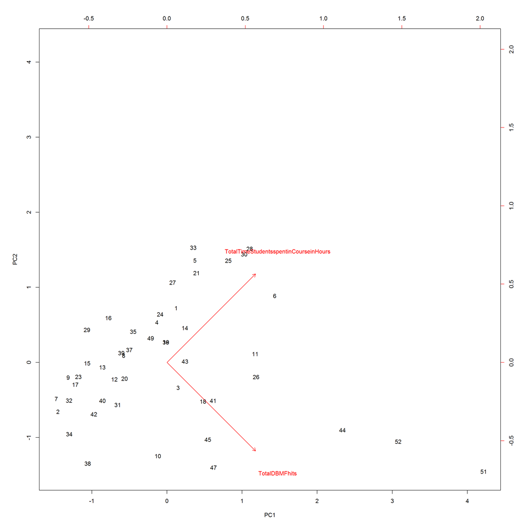

```r
biplot(pca.out, scale=0)
```

*the interesting thing is they are vertical*

to do more, we can redesign the datapca for us:

```r
datapca = grading[,c(8:12)]
datapca = cleanNULL(datapca)
datapca = na.omit(datapca)
str(datapca)
```

```
## 'data.frame':    77 obs. of  5 variables:
##  $ GradeonDiscussionForumAccumulatedpoints: num  22 24 24 19 13 24 20 18 20 24 ...
##  $ GradeonDiscussionLeader                : Factor w/ 10 levels "#NULL!","0","10",..: 6 5 7 6 3 6 6 6 4 5 ...
##  $ GradeonAssignment1                     : Factor w/ 19 levels "#NULL!","0","10",..: 7 7 7 5 4 6 5 6 5 6 ...
##  $ GradeonAssignment2                     : Factor w/ 19 levels "#NULL!","0","10",..: 7 7 8 5 4 8 5 7 8 8 ...
##  $ GradeonFinalPaper                      : Factor w/ 32 levels "#NULL!","0","10",..: 19 15 18 17 15 17 16 16 16 19 ...
##  - attr(*, "na.action")=Class 'omit'  Named int [1:161] 22 37 38 39 40 41 42 43 44 45 ...
##   .. ..- attr(*, "names")= chr [1:161] "22" "37" "38" "39" ...
```

```r
datapca$GradeonDiscussionLeader = as.integer(datapca$GradeonDiscussionLeader)
datapca$GradeonAssignment1 = as.integer(datapca$GradeonAssignment1)
datapca$GradeonAssignment2 = as.integer(datapca$GradeonAssignment2)
datapca$GradeonFinalPaper = as.integer(datapca$GradeonFinalPaper)

# then do the pca
apply(datapca,2,mean)
```

```
## GradeonDiscussionForumAccumulatedpoints
##                               33.078683
##                 GradeonDiscussionLeader
##                                6.545455
##                      GradeonAssignment1
##                               12.324675
##                      GradeonAssignment2
##                                9.129870
##                       GradeonFinalPaper
##                               13.454545
```

```r
apply(datapca,2, var)
```

```
## GradeonDiscussionForumAccumulatedpoints
##                               63.717861
##                 GradeonDiscussionLeader
##                                7.066986
##                      GradeonAssignment1
##                               45.616883
##                      GradeonAssignment2
##                               22.956596
##                       GradeonFinalPaper
##                               54.251196
```

```r
pca.out=prcomp(datapca, scale=TRUE)
pca.out
```

```
## Standard deviations:
## [1] 1.7304845 0.9699847 0.7139630 0.6219575 0.4098521
##
## Rotation:
##                                                PC1         PC2         PC3
## GradeonDiscussionForumAccumulatedpoints  0.3102206  0.79359254 -0.46193635
## GradeonDiscussionLeader                  0.4804064 -0.19128812  0.18923906
## GradeonAssignment1                       0.5400030  0.08445624  0.06422371
## GradeonAssignment2                       0.4832218  0.03990526  0.56020006
## GradeonFinalPaper                       -0.3845339  0.56999513  0.65791686
##                                                 PC4        PC5
## GradeonDiscussionForumAccumulatedpoints  0.03777312 -0.2432325
## GradeonDiscussionLeader                  0.79738062 -0.2469641
## GradeonAssignment1                      -0.06244728  0.8326101
## GradeonAssignment2                      -0.53872650 -0.4010660
## GradeonFinalPaper                        0.26197601  0.1604781
```

```r
names(pca.out)
```

```
## [1] "sdev"     "rotation" "center"   "scale"    "x"
```

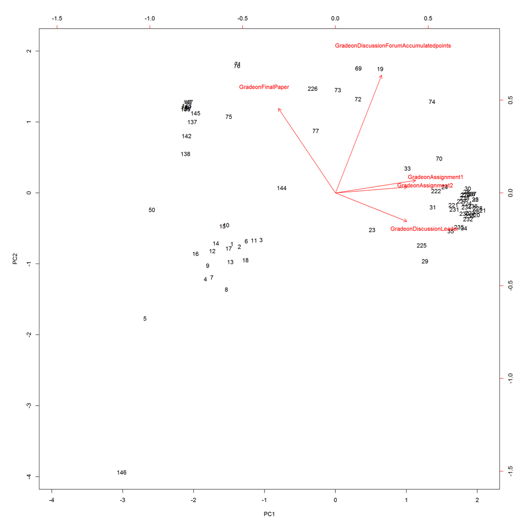

```r
biplot(pca.out, scale=0)
```

from the result we can see that GradeonAssignment1 is the main infuluencing thing in this five variables, with the PC1 equal to `0.5400030`

also, because the var of this five is not too big, then we can se the scale to FALSE to see that whether there are some differences:

```r
pca.out=prcomp(datapca, scale=FALSE)
pca.out
```

```
## Standard deviations:
## [1] 10.470768  7.360753  4.489870  2.573397  1.735097
##
## Rotation:
##                                                PC1         PC2        PC3
## GradeonDiscussionForumAccumulatedpoints  0.5356006  0.72915953  0.4089894
## GradeonDiscussionLeader                  0.1760886 -0.08318986 -0.1329034
## GradeonAssignment1                       0.5926345 -0.07061205 -0.4594418
## GradeonAssignment2                       0.3447601 -0.07163001 -0.5330773
## GradeonFinalPaper                       -0.4604885  0.67178040 -0.5655140
##                                                PC4         PC5
## GradeonDiscussionForumAccumulatedpoints -0.1120511  0.04038099
## GradeonDiscussionLeader                  0.1606499  0.95843650
## GradeonAssignment1                       0.5958963 -0.27860216
## GradeonAssignment2                      -0.7691725 -0.01455236
## GradeonFinalPaper                        0.1221369  0.04402176
```

```r
names(pca.out)
```

```
## [1] "sdev"     "rotation" "center"   "scale"    "x"
```

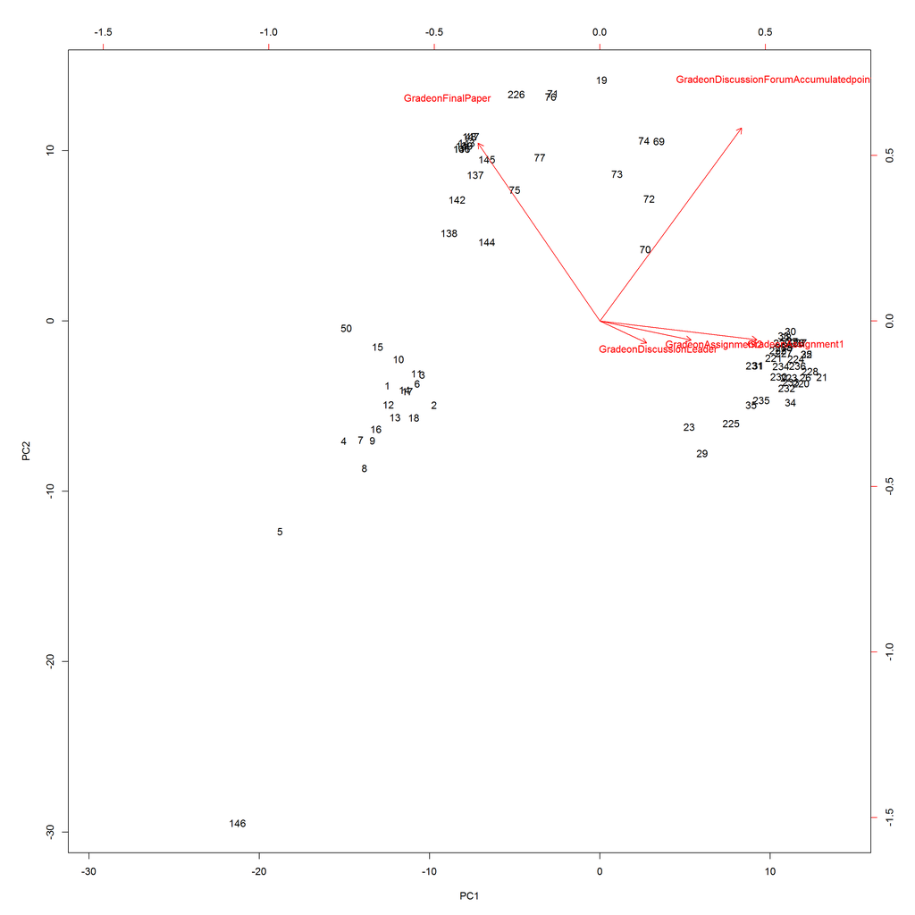

```r
biplot(pca.out, scale=0)
```

this time the result of them is different from the first one, but GradeonAssignment1 is also the main variable in them with PC1 `0.5926345`